# Hypothesis_testing

Team Dataverse(Yashwant, Manoj, Sai and Sravya)

today

```r
#Loading libraries
library(ezids)
library(ggplot2)
library(corrplot)
library(tidyverse)
```

```r
car_data = data.frame(read.csv('cars.csv'))
str(car_data)
```

```
## 'data.frame':    38531 obs. of  30 variables:
##  $ manufacturer_name: chr  "Subaru" "Subaru" "Subaru" "Subaru" ...
##  $ model_name       : chr  "Outback" "Outback" "Forester" "Impreza" ...
##  $ transmission     : chr  "automatic" "automatic" "automatic" "mechanical" ...
##  $ color            : chr  "silver" "blue" "red" "blue" ...
##  $ odometer_value   : int  190000 290000 402000 10000 280000 132449 318280 350000 179000 571317 ...
##  $ year_produced    : int  2010 2002 2001 1999 2001 2011 1998 2004 2010 1999 ...
##  $ engine_fuel      : chr  "gasoline" "gasoline" "gasoline" "gasoline" ...
##  $ engine_has_gas   : chr  "False" "False" "False" "False" ...
##  $ engine_type      : chr  "gasoline" "gasoline" "gasoline" "gasoline" ...
##  $ engine_capacity  : num  2.5 3 2.5 3 2.5 2.5 2.5 2.5 2.5 2.5 ...
##  $ body_type        : chr  "universal" "universal" "suv" "sedan" ...
##  $ has_warranty     : chr  "False" "False" "False" "False" ...
##  $ state            : chr  "owned" "owned" "owned" "owned" ...
##  $ drivetrain       : chr  "all" "all" "all" "all" ...
```

[output cut: 16 more lines]

## Data cleaning

```r
car_data$transmission = as.factor(car_data$transmission)
car_data$engine_fuel = as.factor(car_data$engine_fuel)
car_data$engine_has_gas = as.factor(car_data$engine_has_gas)
car_data$engine_type = as.factor(car_data$engine_type)
car_data$body_type = as.factor(car_data$body_type)
car_data$has_warranty = as.factor(car_data$has_warranty)
car_data$state = as.factor(car_data$state)
car_data$drivetrain = as.factor(car_data$drivetrain)
car_data$is_exchangeable = as.factor(car_data$is_exchangeable)
car_data$location_region = as.factor(car_data$location_region)
```

```r
feature_cols <- c(20:29)
car_data[feature_cols] <- lapply(car_data[feature_cols],factor)
str(car_data)
```

```
## 'data.frame':    38531 obs. of  30 variables:
##  $ manufacturer_name: chr  "Subaru" "Subaru" "Subaru" "Subaru" ...
##  $ model_name       : chr  "Outback" "Outback" "Forester" "Impreza" ...
##  $ transmission     : Factor w/ 2 levels "automatic","mechanical": 1 1 1 2 1 1 1 1 1 1 ...
##  $ color            : chr  "silver" "blue" "red" "blue" ...
##  $ odometer_value   : int  190000 290000 402000 10000 280000 132449 318280 350000 179000 571317 ...
##  $ year_produced    : int  2010 2002 2001 1999 2001 2011 1998 2004 2010 1999 ...
##  $ engine_fuel      : Factor w/ 6 levels "diesel","electric",..: 4 4 4 4 4 4 4 4 4 4 ...
##  $ engine_has_gas   : Factor w/ 2 levels "False","True": 1 1 1 1 1 1 1 1 1 1 ...
##  $ engine_type      : Factor w/ 3 levels "diesel","electric",..: 3 3 3 3 3 3 3 3 3 3 ...
##  $ engine_capacity  : num  2.5 3 2.5 3 2.5 2.5 2.5 2.5 2.5 2.5 ...
##  $ body_type        : Factor w/ 12 levels "cabriolet","coupe",..: 11 11 10 9 11 11 11 9 11 11 ...
##  $ has_warranty     : Factor w/ 2 levels "False","True": 1 1 1 1 1 1 1 1 1 1 ...
##  $ state            : Factor w/ 3 levels "emergency","new",..: 3 3 3 3 3 3 3 3 3 3 ...
##  $ drivetrain       : Factor w/ 3 levels "all","front",..: 1 1 1 1 1 1 1 1 1 1 ...
```

[output cut: 16 more lines]

```r
sapply(car_data, function(x) sum(is.na(x)))
```

```
## manufacturer_name        model_name      transmission             color
##                 0                 0                 0                 0
##    odometer_value     year_produced       engine_fuel    engine_has_gas
##                 0                 0                 0                 0
##       engine_type   engine_capacity         body_type      has_warranty
##                 0                10                 0                 0
##             state        drivetrain         price_usd   is_exchangeable
##                 0                 0                 0                 0
##   location_region  number_of_photos        up_counter         feature_0
##                 0                 0                 0                 0
##         feature_1         feature_2         feature_3         feature_4
##                 0                 0                 0                 0
##         feature_5         feature_6         feature_7         feature_8
##                 0                 0                 0                 0
##         feature_9   duration_listed
##                 0                 0
```

```r
car_data$engine_capacity[is.na(car_data$engine_capacity)] <- 0
mean(car_data$engine_capacity)
```

```
## [1] 2.05
```

```r
median(car_data$engine_capacity)
```

```
## [1] 2
```

```r
getmode <- function(v) {
   uniqv <- unique(v)
   uniqv[which.max(tabulate(match(v, uniqv)))]
}
s <- getmode(car_data$engine_capacity)
s
```

```
## [1] 2
```

```r
car_data$engine_capacity[is.na(car_data$engine_capacity)] <- mean(car_data$engine_capacity,na.rm = TRUE)
sapply(car_data, function(x) sum(is.na(x)))
```

```
## manufacturer_name        model_name      transmission             color
##                 0                 0                 0                 0
##    odometer_value     year_produced       engine_fuel    engine_has_gas
##                 0                 0                 0                 0
##       engine_type   engine_capacity         body_type      has_warranty
##                 0                 0                 0                 0
##             state        drivetrain         price_usd   is_exchangeable
##                 0                 0                 0                 0
##   location_region  number_of_photos        up_counter         feature_0
##                 0                 0                 0                 0
##         feature_1         feature_2         feature_3         feature_4
##                 0                 0                 0                 0
##         feature_5         feature_6         feature_7         feature_8
##                 0                 0                 0                 0
##         feature_9   duration_listed
##                 0                 0
```

## Unknown features(feature0 to feature9)

In this dataset, we have 10 unknown features, and we are not aware that which part of the car these features are representing. So, to test the impact, we designed the t-test for all the features.

H0: there is no difference in the mean price of the cars and the mean price based on unknown features. H1: there is a difference in the mean price of the cars and the mean price based on unknown features.

### Feature 0

Is feature_0 impacting the average car price?

```r
with_feature_0<-subset(car_data,feature_0 == 'True')
without_feature_0<-subset(car_data,feature_0 == 'False')
```

```r
mean_price = mean(car_data$price_usd)
mean_price
```

```
## [1] 6640
```

```r
Hypothesis_test_price_with_feature0 = t.test(x=with_feature_0$price_usd,mu = mean_price ,conf.level = 0.95)
#default conf.level = 0.95
Hypothesis_test_price_with_feature0
```

```
##
##  One Sample t-test
##
## data:  with_feature_0$price_usd
## t = -40, df = 8805, p-value <2e-16
## alternative hypothesis: true mean is not equal to 6640
## 95 percent confidence interval:
##  3867 4125
## sample estimates:
## mean of x
##      3996
```

```r
Hypothesis_test_price_without_feature0 = t.test(x=without_feature_0$price_usd,mu = mean_price ,conf.level = 0.95)
#default conf.level = 0.95
Hypothesis_test_price_without_feature0
```

```
##
##  One Sample t-test
##
## data:  without_feature_0$price_usd
## t = 21, df = 29724, p-value <2e-16
## alternative hypothesis: true mean is not equal to 6640
## 95 percent confidence interval:
##  7352 7495
## sample estimates:
## mean of x
##      7423
```

We got low price interval if feature0 is in the car. So probably its outdated feature.

### Feature 1

Is feature_1 impacting the average car price?

```r
with_feature_1<-subset(car_data,feature_1 == 'True')
without_feature_1<-subset(car_data,feature_1 == 'False')
```

```r
mean_price = mean(car_data$price_usd)
mean_price
```

```
## [1] 6640
```

```r
Hypothesis_test_price_with_feature1 = t.test(x=with_feature_1$price_usd,mu = mean_price ,conf.level = 0.95)
#default conf.level = 0.95
Hypothesis_test_price_with_feature1
```

```
##
##  One Sample t-test
##
## data:  with_feature_1$price_usd
## t = 33, df = 23395, p-value <2e-16
## alternative hypothesis: true mean is not equal to 6640
## 95 percent confidence interval:
##  7883 8042
## sample estimates:
## mean of x
##      7963
```

```r
Hypothesis_test_price_without_feature1 = t.test(x=without_feature_1$price_usd,mu = mean_price ,conf.level = 0.95)
#default conf.level = 0.95
Hypothesis_test_price_without_feature1
```

```
##
##  One Sample t-test
##
## data:  without_feature_1$price_usd
## t = -40, df = 15134, p-value <2e-16
## alternative hypothesis: true mean is not equal to 6640
## 95 percent confidence interval:
##  4496 4695
## sample estimates:
## mean of x
##      4596
```

### Feature 2

Is feature_2 impacting the average car price?

```r
with_feature_2<-subset(car_data,feature_2 == 'True')
without_feature_2<-subset(car_data,feature_2 == 'False')
```

```r
mean_price = mean(car_data$price_usd)
mean_price
```

```
## [1] 6640
```

```r
Hypothesis_test_price_with_feature2 = t.test(x=with_feature_2$price_usd,mu = mean_price ,conf.level = 0.95)
#default conf.level = 0.95
Hypothesis_test_price_with_feature2
```

```
##
##  One Sample t-test
##
## data:  with_feature_2$price_usd
## t = 48, df = 8623, p-value <2e-16
## alternative hypothesis: true mean is not equal to 6640
## 95 percent confidence interval:
##  10521 10855
## sample estimates:
## mean of x
##     10688
```

```r
Hypothesis_test_price_without_feature2 = t.test(x=without_feature_2$price_usd,mu = mean_price ,conf.level = 0.95)
#default conf.level = 0.95
Hypothesis_test_price_without_feature2
```

```
##
##  One Sample t-test
##
## data:  without_feature_2$price_usd
## t = -37, df = 29906, p-value <2e-16
## alternative hypothesis: true mean is not equal to 6640
## 95 percent confidence interval:
##  5411 5534
## sample estimates:
## mean of x
##      5473
```

### Feature_3

```r
with_feature_3<-subset(car_data,feature_3 == 'True')
without_feature_3<-subset(car_data,feature_3 == 'False')
```

```r
mean_price = mean(car_data$price_usd)
mean_price
```

```
## [1] 6640
```

```r
Hypothesis_test_price_with_feature3 = t.test(x=with_feature_3$price_usd,mu = mean_price ,conf.level = 0.95)
#default conf.level = 0.95
Hypothesis_test_price_with_feature3
```

```
##
##  One Sample t-test
##
## data:  with_feature_3$price_usd
## t = 69, df = 10626, p-value <2e-16
## alternative hypothesis: true mean is not equal to 6640
## 95 percent confidence interval:
##  11405 11685
## sample estimates:
## mean of x
##     11545
```

```r
Hypothesis_test_price_without_feature3 = t.test(x=without_feature_3$price_usd,mu = mean_price ,conf.level = 0.95)
#default conf.level = 0.95
Hypothesis_test_price_without_feature3
```

```
##
##  One Sample t-test
##
## data:  without_feature_3$price_usd
## t = -64, df = 27903, p-value <2e-16
## alternative hypothesis: true mean is not equal to 6640
## 95 percent confidence interval:
##  4715 4829
## sample estimates:
## mean of x
##      4772
```

### Feature_4

```r
with_feature_4<-subset(car_data,feature_4 == 'True')
without_feature_4<-subset(car_data,feature_4 == 'False')
```

```r
mean_price = mean(car_data$price_usd)
mean_price
```

```
## [1] 6640
```

```r
Hypothesis_test_price_with_feature4 = t.test(x=with_feature_4$price_usd,mu = mean_price ,conf.level = 0.95)
#default conf.level = 0.95
Hypothesis_test_price_with_feature4
```

```
##
##  One Sample t-test
##
## data:  with_feature_4$price_usd
## t = 47, df = 9303, p-value <2e-16
## alternative hypothesis: true mean is not equal to 6640
## 95 percent confidence interval:
##  10310 10629
## sample estimates:
## mean of x
##     10470
```

```r
Hypothesis_test_price_without_feature4 = t.test(x=without_feature_4$price_usd,mu = mean_price ,conf.level = 0.95)
#default conf.level = 0.95
Hypothesis_test_price_without_feature4
```

```
##
##  One Sample t-test
##
## data:  without_feature_4$price_usd
## t = -39, df = 29226, p-value <2e-16
## alternative hypothesis: true mean is not equal to 6640
## 95 percent confidence interval:
##  5359 5482
## sample estimates:
## mean of x
##      5421
```

### Feature_5

```r
with_feature_5<-subset(car_data,feature_5 == 'True')
without_feature_5<-subset(car_data,feature_5 == 'False')
```

```r
mean_price = mean(car_data$price_usd)
mean_price
```

```
## [1] 6640
```

```r
Hypothesis_test_price_with_feature5 = t.test(x=with_feature_5$price_usd,mu = mean_price ,conf.level = 0.95)
#default conf.level = 0.95
Hypothesis_test_price_with_feature5
```

```
##
##  One Sample t-test
##
## data:  with_feature_5$price_usd
## t = 62, df = 13719, p-value <2e-16
## alternative hypothesis: true mean is not equal to 6640
## 95 percent confidence interval:
##  10277 10514
## sample estimates:
## mean of x
##     10396
```

```r
Hypothesis_test_price_without_feature5 = t.test(x=without_feature_5$price_usd,mu = mean_price ,conf.level = 0.95)
#default conf.level = 0.95
Hypothesis_test_price_without_feature5
```

```
##
##  One Sample t-test
##
## data:  without_feature_5$price_usd
## t = -66, df = 24810, p-value <2e-16
## alternative hypothesis: true mean is not equal to 6640
## 95 percent confidence interval:
##  4502 4625
## sample estimates:
## mean of x
##      4563
```

### Feature_6

```r
with_feature_6<-subset(car_data,feature_6 == 'True')
without_feature_6<-subset(car_data,feature_6 == 'False')
```

```r
mean_price = mean(car_data$price_usd)
mean_price
```

```
## [1] 6640
```

```r
Hypothesis_test_price_with_feature6 = t.test(x=with_feature_6$price_usd,mu = mean_price ,conf.level = 0.95)
#default conf.level = 0.95
Hypothesis_test_price_with_feature6
```

```
##
##  One Sample t-test
##
## data:  with_feature_6$price_usd
## t = 66, df = 6587, p-value <2e-16
## alternative hypothesis: true mean is not equal to 6640
## 95 percent confidence interval:
##  12844 13224
## sample estimates:
## mean of x
##     13034
```

```r
Hypothesis_test_price_without_feature6 = t.test(x=without_feature_6$price_usd,mu = mean_price ,conf.level = 0.95)
#default conf.level = 0.95
Hypothesis_test_price_without_feature6
```

```
##
##  One Sample t-test
##
## data:  without_feature_6$price_usd
## t = -45, df = 31942, p-value <2e-16
## alternative hypothesis: true mean is not equal to 6640
## 95 percent confidence interval:
##  5264 5378
## sample estimates:
## mean of x
##      5321
```

### Feature_7

```r
with_feature_7<-subset(car_data,feature_7 == 'True')
without_feature_7<-subset(car_data,feature_7 == 'False')
```

```r
mean_price = mean(car_data$price_usd)
mean_price
```

```
## [1] 6640
```

```r
Hypothesis_test_price_with_feature7 = t.test(x=with_feature_7$price_usd,mu = mean_price ,conf.level = 0.95)
#default conf.level = 0.95
Hypothesis_test_price_with_feature7
```

```
##
##  One Sample t-test
##
## data:  with_feature_7$price_usd
## t = 73, df = 10161, p-value <2e-16
## alternative hypothesis: true mean is not equal to 6640
## 95 percent confidence interval:
##  11850 12139
## sample estimates:
## mean of x
##     11994
```

```r
Hypothesis_test_price_without_feature7 = t.test(x=without_feature_7$price_usd,mu = mean_price ,conf.level = 0.95)
#default conf.level = 0.95
Hypothesis_test_price_without_feature7
```

```
##
##  One Sample t-test
##
## data:  without_feature_7$price_usd
## t = -68, df = 28368, p-value <2e-16
## alternative hypothesis: true mean is not equal to 6640
## 95 percent confidence interval:
##  4667 4777
## sample estimates:
## mean of x
##      4722
```

### Feature_8

```r
with_feature_8<-subset(car_data,feature_8 == 'True')
without_feature_8<-subset(car_data,feature_8 == 'False')
```

```r
mean_price = mean(car_data$price_usd)
mean_price
```

```
## [1] 6640
```

```r
Hypothesis_test_price_with_feature8 = t.test(x=with_feature_8$price_usd,mu = mean_price ,conf.level = 0.95)
#default conf.level = 0.95
Hypothesis_test_price_with_feature8
```

```
##
##  One Sample t-test
##
## data:  with_feature_8$price_usd
## t = 63, df = 16002, p-value <2e-16
## alternative hypothesis: true mean is not equal to 6640
## 95 percent confidence interval:
##   9959 10172
## sample estimates:
## mean of x
##     10065
```

```r
Hypothesis_test_price_without_feature8 = t.test(x=without_feature_8$price_usd,mu = mean_price ,conf.level = 0.95)
#default conf.level = 0.95
Hypothesis_test_price_without_feature8
```

```
##
##  One Sample t-test
##
## data:  without_feature_8$price_usd
## t = -77, df = 22527, p-value <2e-16
## alternative hypothesis: true mean is not equal to 6640
## 95 percent confidence interval:
##  4144 4269
## sample estimates:
## mean of x
##      4207
```

### Feature_9

```r
with_feature_9<-subset(car_data,feature_9 == 'True')
without_feature_9<-subset(car_data,feature_9 == 'False')
```

```r
mean_price = mean(car_data$price_usd)
mean_price
```

```
## [1] 6640
```

```r
Hypothesis_test_price_with_feature9 = t.test(x=with_feature_9$price_usd,mu = mean_price ,conf.level = 0.95)
#default conf.level = 0.95
Hypothesis_test_price_with_feature9
```

```
##
##  One Sample t-test
##
## data:  with_feature_9$price_usd
## t = 33, df = 22324, p-value <2e-16
## alternative hypothesis: true mean is not equal to 6640
## 95 percent confidence interval:
##  8010 8185
## sample estimates:
## mean of x
##      8098
```

```r
Hypothesis_test_price_without_feature9 = t.test(x=without_feature_9$price_usd,mu = mean_price ,conf.level = 0.95)
#default conf.level = 0.95
Hypothesis_test_price_without_feature9
```

```
##
##  One Sample t-test
##
## data:  without_feature_9$price_usd
## t = -47, df = 16205, p-value <2e-16
## alternative hypothesis: true mean is not equal to 6640
## 95 percent confidence interval:
##  4548 4716
## sample estimates:
## mean of x
##      4632
```

As we are getting the p-value significantly less and we can clearly see that the mean price is not falling in the price range we got based on the unknown feature category.

## Anova test on car brands

All car brands have same average car price or not?

```r
price_aov<-aov(price_usd ~ manufacturer_name, data=car_data)
price_aov
```

```
## Call:
##    aov(formula = price_usd ~ manufacturer_name, data = car_data)
##
## Terms:
##                 manufacturer_name Residuals
## Sum of Squares           2.94e+11  1.30e+12
## Deg. of Freedom                54     38476
##
## Residual standard error: 5807
## Estimated effects may be unbalanced
```

```r
xkabledply(price_aov, title = 'Anova test result impact of manufacturer_name on car price')
```

Anova test result impact of manufacturer_name on car price

|  | Df | Sum Sq | Mean Sq | F value | Pr(>F) |
| --- | --- | --- | --- | --- | --- |
| manufacturer_name | 54 | 2.94e+11 | 5.45e+09 | 162 | 0 |
| Residuals | 38476 | 1.30e+12 | 3.37e+07 | NA | NA |

In this test, we are checking that is there any significant difference in the mean price on the basis of car manufacturer. H0: there is no difference in the mean prices of the cars based on manufacturer H1: there is a difference in the mean prices of the cars based on manufacturer

If p≤α, reject H0; otherwise, do not reject H0.

As we got p value less than α hence we reject the null hypothesis. It means there is a significant difference in the mean price based on manufacturer.

## Warranty

is there any impact of warranty of a car on the resale price?

```r
with_warranty<-subset(car_data,has_warranty == 'True')
without_warranty<-subset(car_data,has_warranty == 'False')
```

```r
mean_price = mean(car_data$price_usd)
mean_price
```

```
## [1] 6640
```

```r
Hypothesis_test_price_with_warranty = t.test(x=with_warranty$price_usd,mu = mean_price ,conf.level = 0.95)
#default conf.level = 0.95
Hypothesis_test_price_with_warranty
```

```
##
##  One Sample t-test
##
## data:  with_warranty$price_usd
## t = 37, df = 448, p-value <2e-16
## alternative hypothesis: true mean is not equal to 6640
## 95 percent confidence interval:
##  22635 24452
## sample estimates:
## mean of x
##     23543
```

```r
Hypothesis_test_price_without_warranty = t.test(x=without_warranty$price_usd,mu = mean_price ,conf.level = 0.95)
#default conf.level = 0.95
Hypothesis_test_price_without_warranty
```

```
##
##  One Sample t-test
##
## data:  without_warranty$price_usd
## t = -6, df = 38081, p-value = 2e-10
## alternative hypothesis: true mean is not equal to 6640
## 95 percent confidence interval:
##  6379 6502
## sample estimates:
## mean of x
##      6441
```

as we can see that mean price of the whole car dataset is not falling under the time interval we got after separating the data based on warranty feature. Also there is significant difference in the mean car price as we got price intervals which are not overlapping.

## Chi square test of independence on Year of manufacture and price

Car resale prices are dependent on the year of manufacture?

```r
p_usd.intrv = cut(car_data$price_usd, c(0,10000,20000,30000,40000,50000))
year.intrv = cut(car_data$year_produced, c(1940,1950,1960,1970,1980,1990,2000,2010,2020))
lists <- list(price_intvl = as.character(p_usd.intrv),yr_interval = as.character(year.intrv))
df <- as.data.frame(do.call(cbind, lists))
conTable = table(df)
print(conTable)
```

```
##                yr_interval
## price_intvl     (1.94e+03,1.95e+03] (1.95e+03,1.96e+03] (1.96e+03,1.97e+03]
##   (0,1e+04]                       1                  19                  48
##   (1e+04,2e+04]                   0                   1                   4
##   (2e+04,3e+04]                   1                   1                   1
##   (3e+04,4e+04]                   0                   0                   0
##   (4e+04,5e+04]                   0                   0                   0
##                yr_interval
## price_intvl     (1.97e+03,1.98e+03] (1.98e+03,1.99e+03] (1.99e+03,2e+03]
##   (0,1e+04]                     129                2011            13078
##   (1e+04,2e+04]                   2                   7               50
##   (2e+04,3e+04]                   1                   1                2
##   (3e+04,4e+04]                   0                   0                0
##   (4e+04,5e+04]                   0                   0                0
##                yr_interval
## price_intvl     (2.01e+03,2.02e+03] (2e+03,2.01e+03]
##   (0,1e+04]                    2148            13307
##   (1e+04,2e+04]                3743             2446
##   (2e+04,3e+04]                 895              169
##   (3e+04,4e+04]                 330               15
##   (4e+04,5e+04]                 120                1
```

```r
head(df,3)
```

```
##     price_intvl      yr_interval
## 1 (1e+04,2e+04] (2e+03,2.01e+03]
## 2     (0,1e+04] (2e+03,2.01e+03]
## 3     (0,1e+04] (2e+03,2.01e+03]
```

```r
chitest = chisq.test(conTable)
chitest
```

```
##
##  Pearson's Chi-squared test
##
## data:  conTable
## X-squared = 15898, df = 28, p-value <2e-16
```

With the chi square test of independence, we are checking that resale car prices are dependent on the year of manufacture or not. H0: Car prices and year of production are independent of each other. H1: Car prices and year of production are dependent of each other.

If p≤α, reject H0; otherwise, do not reject H0.

as we got p value less than 0.05 hance we are rejecting the null hypothesis.

It means prices and year of production are dependent of each other

## corrplot

Correlation plot between the numerical features is considered

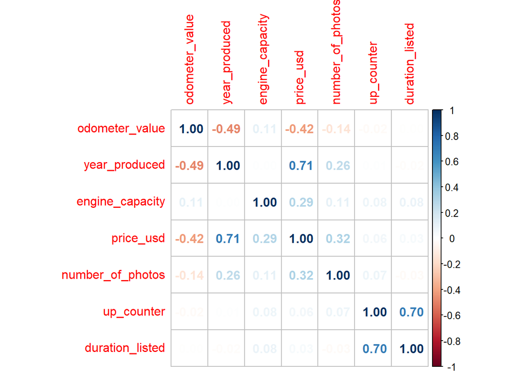

```r
corrplot(cor(cars_numerical), method = 'number')
```

The above correlation plot shows the relation between all the numerical features and the price_usd. Here, odometer_value has negative correlation with price(cc=-0.42). Year of production is highly correlated among the others and the least correlated one is up_counter and duration_listed.

ANOVA is helpful for testing three or more variables.It is similar to multiple two-sample t-tests.The one-way ANOVA is used to determine whether there are any statistically significant differences between the means of three or more independent (unrelated) groups.

One way Anova test for color and body type is performed

Setting the Hypothesis The null hypothesis states that the mean resale price in usd is equal among all color groups Null Hypothesis H0 : all means are equal Alternate Hypothesis H1 : not all means are equal

Decide on the significance level significance level is alpha=0.05

## Anova test for car color

```r
df_aov_1 = aov(price_usd ~  color , car_data)
summary(df_aov_1)
```

```
##                Df   Sum Sq  Mean Sq F value Pr(>F)
## color          11 1.70e+11 1.55e+10     420 <2e-16 ***
## Residuals   38519 1.42e+12 3.69e+07
## ---
## Signif. codes:  0 '***' 0.001 '**' 0.01 '*' 0.05 '.' 0.1 ' ' 1
```

If p≤α, reject H0; otherwise, do not reject H0. The p-value is less than the specified significance level of 0.05; we reject H0. The test results are statistically significant at the 5% level and provide very strong evidence against the null hypothesis. Conclusion from anova test: Again, we may conclude that at the 5% significance level, the data provides very strong evidence to conclude that at least one pair of group means of color is different from each other.

Setting the Hypothesis The null hypothesis states that the mean resale price in usd is equal among all groups of car body type Null Hypothesis H0 : all means are equal Alternate Hypothesis H1 : not all means are equal

Decide on the significance level significance level is alpha=0.05

## Anova test for body type

```r
df_aov_4 = aov(price_usd ~  body_type , car_data)
summary(df_aov_4)
```

```
##                Df   Sum Sq  Mean Sq F value Pr(>F)
## body_type      11 3.50e+11 3.18e+10     986 <2e-16 ***
## Residuals   38519 1.24e+12 3.23e+07
## ---
## Signif. codes:  0 '***' 0.001 '**' 0.01 '*' 0.05 '.' 0.1 ' ' 1
```

If p≤α, reject H0; otherwise, do not reject H0. The p-value is less than the specified significance level of 0.05; we reject H0. The test results are statistically significant at the 5% level and provide very strong evidence against the null hypothesis. Conclusion from anova test: Again, we may conclude that at the 5% significance level, the data provides very strong evidence to conclude that at least one pair of group means of body type is different from each other.

## Testing engine_fuel type an engine_type

In order to showcase the one-way ANOVA hypothesis test we examine the mean resale prices of cars, grouped by their engine fuel type. To make it clear, in this example the classification/grouping is done by one variable, the major variable, the so-called factor, thus we are conducting a one-way ANOVA. In this exercise we want to test if the mean annual resale price of cars is different for different engine fuel types. In the same way, one way anova test is performed on the engine type.

Setting the Hypothesis The null hypothesis states that the mean resale price in usd is equal among all groups of engine fuel types. Null Hypothesis H0 : μ1=μ2=μ3=μ4=μ5=μ6 Alternate Hypothesis H1 : not all means are equal

Decide on the significance level significance level is alpha=0.05

```r
df_aov_2 = aov(price_usd~  engine_fuel , car_data)
summary(df_aov_2)
```

```
##                Df   Sum Sq  Mean Sq F value Pr(>F)
## engine_fuel     5 2.27e+10 4.54e+09     111 <2e-16 ***
## Residuals   38525 1.57e+12 4.07e+07
## ---
## Signif. codes:  0 '***' 0.001 '**' 0.01 '*' 0.05 '.' 0.1 ' ' 1
```

If p≤α, reject H0; otherwise, do not reject H0. The p-value is less than the specified significance level of 0.05; we reject H0. The test results are statistically significant at the 5% level and provide very strong evidence against the null hypothesis. Conclusion from anova test: Again, we may conclude that at the 5% significance level, the data provides very strong evidence to conclude that at least one pair of group means of engine fuel type is different from each other.

Setting the Hypothesis The null hypothesis states that the mean resale price in usd is equal among all groups of engine types. Null Hypothesis H0 : μ1=μ2=μ3 Alternate Hypothesis H1 : not all means are equal

Decide on the significance level Significance level is alpha=0.05

```r
df_aov_3 = aov(price_usd~  engine_type , car_data)
summary(df_aov_3)
```

```
##                Df   Sum Sq  Mean Sq F value Pr(>F)
## engine_type     2 1.28e+10 6.38e+09     156 <2e-16 ***
## Residuals   38528 1.58e+12 4.10e+07
## ---
## Signif. codes:  0 '***' 0.001 '**' 0.01 '*' 0.05 '.' 0.1 ' ' 1
```

If p≤α, reject H0; otherwise, do not reject H0. The p-value is less than the specified significance level of 0.05; we reject H0. The test results are statistically significant at the 5% level and provide very strong evidence against the null hypothesis.

Conclusion from anova test: Again, we may conclude that at the 5% significance level, the data provides very strong evidence to conclude that at least one pair of group means of engine type is different from each other.

## t-test for transmission type as there are only two sub groups

```r
summary(car_data$transmission)
t_auto = subset(car_data, transmission == "automatic")
t_mechanical = subset(car_data, transmission == "mechanical")
t.test(x = t_auto$price_usd, y = t_mechanical$price_usd, conf.level = 0.99)
```

[output not shown]

## Anova test on car brands

All car brands have same average car price or not?

```r
price_aov<-aov(price_usd ~ manufacturer_name, data=car_data)
price_aov
```

```
## Call:
##    aov(formula = price_usd ~ manufacturer_name, data = car_data)
##
## Terms:
##                 manufacturer_name Residuals
## Sum of Squares           2.94e+11  1.30e+12
## Deg. of Freedom                54     38476
##
## Residual standard error: 5807
## Estimated effects may be unbalanced
```

```r
xkabledply(price_aov, title = 'Anova test result impact of manufacturer_name on car price')
```

Anova test result impact of manufacturer_name on car price

|  | Df | Sum Sq | Mean Sq | F value | Pr(>F) |
| --- | --- | --- | --- | --- | --- |
| manufacturer_name | 54 | 2.94e+11 | 5.45e+09 | 162 | 0 |
| Residuals | 38476 | 1.30e+12 | 3.37e+07 | NA | NA |

As we have 55 car brands, Running the test on all car brands to check if there is any significant difference in mean car price based on manufacturer.

H0: there is no difference in the mean prices based on car brands. H1: there is a significant difference in the mean prices based on car brands.

As we got p value less than 0.05, we will reject the null hypothesis. It means there is a significant difference based in the mean car prices based on manufacturer

```r
car_data_top_10 <- car_data[car_data$manufacturer_name %in% c("Acura","Buick","Cadillac","Infiniti","Jaguar","Land Rover","Lexus","Mini","Porsche","Skoda"),]
nrow(car_data_top_10)
```

```
## [1] 1986
```

```r
price_aov<-aov(price_usd ~ manufacturer_name, data=car_data_top_10)
price_aov
```

```
## Call:
##    aov(formula = price_usd ~ manufacturer_name, data = car_data_top_10)
##
## Terms:
##                 manufacturer_name Residuals
## Sum of Squares           4.73e+09  1.81e+11
## Deg. of Freedom                 9      1976
##
## Residual standard error: 9573
## Estimated effects may be unbalanced
```

```r
xkabledply(price_aov, title = 'Anova test result impact of top 10 manufacturer_name on car price')
```

Anova test result impact of top 10 manufacturer_name on car price

|  | Df | Sum Sq | Mean Sq | F value | Pr(>F) |
| --- | --- | --- | --- | --- | --- |
| manufacturer_name | 9 | 4.73e+09 | 5.26e+08 | 5.74 | 0 |
| Residuals | 1976 | 1.81e+11 | 9.16e+07 | NA | NA |

## Anova test on Drivetrain

Is there any change in the resale price based on drive train feature?

```r
cartrain_aov<-aov(price_usd ~ drivetrain, data=car_data)
cartrain_aov
```

```
## Call:
##    aov(formula = price_usd ~ drivetrain, data = car_data)
##
## Terms:
##                 drivetrain Residuals
## Sum of Squares    3.10e+11  1.28e+12
## Deg. of Freedom          2     38528
##
## Residual standard error: 5769
## Estimated effects may be unbalanced
```

```r
xkabledply(cartrain_aov, title = 'Anova test result impact of drivetrain on car prices')
```

Anova test result impact of drivetrain on car prices

|  | Df | Sum Sq | Mean Sq | F value | Pr(>F) |
| --- | --- | --- | --- | --- | --- |
| drivetrain | 2 | 3.10e+11 | 1.55e+11 | 4658 | 0 |
| Residuals | 38528 | 1.28e+12 | 3.33e+07 | NA | NA |